# INN_Learner_Notebook_Full_codeOS

### Neural Network with Balanced Data (by applying SMOTE), Adam Optimizer, and Dropout

```python
backend.clear_session()
#Fixing the seed for random number generators so that we can ensure we receive the same output everytime
np.random.seed(2)
random.seed(2)
tf.random.set_seed(2)
```

```python
#Initializing the model
model_5 = Sequential()
# Complete the code to add required # of neurons to the input layer with relu as activation function
model_5.add(Dense(64,activation='relu',input_dim = X_train_smote.shape[1]))
#Complete the code to add dropout rate
model_5.add(Dropout(0.2))
# Complete the code to add required # neurons to the hidden layer with any activation function.
model_5.add(Dense(32,activation='relu'))
# Complete the code to add dropout rate.
model_5.add(Dropout(0.1))
# Adding hidden layer with 8 neurons with relu as activation function
model_5.add(Dense(8,activation='relu'))
# Complete the code to add the required number of neurons in the output layer with a suitable activation function.
model_5.add(Dense(1, activation = 'sigmoid'))
```

```python
#Complete the code to use Adam as the optimizer.
optimizer = tf.keras.optimizers.Adam()
# uncomment one of the following lines to define the metric to be used
# metric = 'accuracy'
metric = keras.metrics.Recall()
# metric = keras.metrics.Precision()
# metric = keras.metrics.F1Score()
```

```python
# Complete the code to compile the model with binary cross entropy as loss function and recall as the metric
model_5.compile(loss='binary_crossentropy',optimizer=optimizer,metrics=[metric])
```

```python
model_5.summary()
```

```
Model: "sequential"
```

```
┏━━━━━━━━━━━━━━━━━━━━━━━━━━━━━━━━━━━━━━┳━━━━━━━━━━━━━━━━━━━━━━━━━━━━━┳━━━━━━━━━━━━━━━━━┓
┃ Layer (type)                         ┃ Output Shape                ┃         Param # ┃
┡━━━━━━━━━━━━━━━━━━━━━━━━━━━━━━━━━━━━━━╇━━━━━━━━━━━━━━━━━━━━━━━━━━━━━╇━━━━━━━━━━━━━━━━━┩
│ dense (Dense)                        │ (None, 64)                  │             768 │
├──────────────────────────────────────┼─────────────────────────────┼─────────────────┤
│ dropout (Dropout)                    │ (None, 64)                  │               0 │
├──────────────────────────────────────┼─────────────────────────────┼─────────────────┤
│ dense_1 (Dense)                      │ (None, 32)                  │           2,080 │
├──────────────────────────────────────┼─────────────────────────────┼─────────────────┤
│ dropout_1 (Dropout)                  │ (None, 32)                  │               0 │
├──────────────────────────────────────┼─────────────────────────────┼─────────────────┤
│ dense_2 (Dense)                      │ (None, 8)                   │             264 │
├──────────────────────────────────────┼─────────────────────────────┼─────────────────┤
│ dense_3 (Dense)                      │ (None, 1)                   │               9 │
└──────────────────────────────────────┴─────────────────────────────┴─────────────────┘
```

```
 Total params: 3,121 (12.19 KB)
```

```
 Trainable params: 3,121 (12.19 KB)
```

```
 Non-trainable params: 0 (0.00 B)
```

```python
history_5 = model_5.fit(
    X_train_smote,y_train_smote,
    batch_size=batch_size, ## Complete the code to specify the batch size to use
    epochs=epochs, ## Complete the code to specify the number of epochs
    verbose=1,
    validation_data = (X_val,y_val))
```

```
160/160 ━━━━━━━━━━━━━━━━━━━━ 3s 4ms/step - loss: 0.6518 - recall: 0.6083 - val_loss: 0.5721 - val_recall: 0.6656
160/160 ━━━━━━━━━━━━━━━━━━━━ 0s 3ms/step - loss: 0.5585 - recall: 0.7004 - val_loss: 0.5507 - val_recall: 0.6319
160/160 ━━━━━━━━━━━━━━━━━━━━ 0s 3ms/step - loss: 0.5383 - recall: 0.7257 - val_loss: 0.5369 - val_recall: 0.6319
160/160 ━━━━━━━━━━━━━━━━━━━━ 1s 2ms/step - loss: 0.5174 - recall: 0.7388 - val_loss: 0.5318 - val_recall: 0.6626
160/160 ━━━━━━━━━━━━━━━━━━━━ 0s 3ms/step - loss: 0.5118 - recall: 0.7382 - val_loss: 0.5132 - val_recall: 0.6503
160/160 ━━━━━━━━━━━━━━━━━━━━ 1s 3ms/step - loss: 0.4982 - recall: 0.7510 - val_loss: 0.5188 - val_recall: 0.6840
160/160 ━━━━━━━━━━━━━━━━━━━━ 0s 3ms/step - loss: 0.4874 - recall: 0.7579 - val_loss: 0.4988 - val_recall: 0.6871
160/160 ━━━━━━━━━━━━━━━━━━━━ 0s 3ms/step - loss: 0.4783 - recall: 0.7662 - val_loss: 0.4986 - val_recall: 0.7270
160/160 ━━━━━━━━━━━━━━━━━━━━ 1s 3ms/step - loss: 0.4785 - recall: 0.7723 - val_loss: 0.4844 - val_recall: 0.7178
160/160 ━━━━━━━━━━━━━━━━━━━━ 1s 4ms/step - loss: 0.4681 - recall: 0.7672 - val_loss: 0.4787 - val_recall: 0.7025
160/160 ━━━━━━━━━━━━━━━━━━━━ 1s 4ms/step - loss: 0.4514 - recall: 0.7798 - val_loss: 0.4765 - val_recall: 0.7147
160/160 ━━━━━━━━━━━━━━━━━━━━ 1s 4ms/step - loss: 0.4487 - recall: 0.7869 - val_loss: 0.4748 - val_recall: 0.7270
160/160 ━━━━━━━━━━━━━━━━━━━━ 1s 4ms/step - loss: 0.4418 - recall: 0.7979 - val_loss: 0.4726 - val_recall: 0.7147
160/160 ━━━━━━━━━━━━━━━━━━━━ 1s 4ms/step - loss: 0.4380 - recall: 0.7934 - val_loss: 0.4624 - val_recall: 0.7086
160/160 ━━━━━━━━━━━━━━━━━━━━ 1s 3ms/step - loss: 0.4338 - recall: 0.7920 - val_loss: 0.4590 - val_recall: 0.7086
160/160 ━━━━━━━━━━━━━━━━━━━━ 1s 2ms/step - loss: 0.4222 - recall: 0.8058 - val_loss: 0.4666 - val_recall: 0.7147
160/160 ━━━━━━━━━━━━━━━━━━━━ 1s 3ms/step - loss: 0.4202 - recall: 0.8043 - val_loss: 0.4608 - val_recall: 0.7055
160/160 ━━━━━━━━━━━━━━━━━━━━ 1s 3ms/step - loss: 0.4197 - recall: 0.7943 - val_loss: 0.4604 - val_recall: 0.7209
160/160 ━━━━━━━━━━━━━━━━━━━━ 1s 3ms/step - loss: 0.4131 - recall: 0.8051 - val_loss: 0.4536 - val_recall: 0.6718
160/160 ━━━━━━━━━━━━━━━━━━━━ 0s 2ms/step - loss: 0.4124 - recall: 0.8009 - val_loss: 0.4544 - val_recall: 0.6963
160/160 ━━━━━━━━━━━━━━━━━━━━ 0s 3ms/step - loss: 0.4114 - recall: 0.8098 - val_loss: 0.4545 - val_recall: 0.6840
160/160 ━━━━━━━━━━━━━━━━━━━━ 1s 3ms/step - loss: 0.4057 - recall: 0.8164 - val_loss: 0.4526 - val_recall: 0.7025
160/160 ━━━━━━━━━━━━━━━━━━━━ 1s 3ms/step - loss: 0.4027 - recall: 0.8162 - val_loss: 0.4566 - val_recall: 0.6902
160/160 ━━━━━━━━━━━━━━━━━━━━ 1s 3ms/step - loss: 0.3986 - recall: 0.8159 - val_loss: 0.4490 - val_recall: 0.6718
160/160 ━━━━━━━━━━━━━━━━━━━━ 1s 3ms/step - loss: 0.4006 - recall: 0.8104 - val_loss: 0.4504 - val_recall: 0.6840
```

**Loss function**

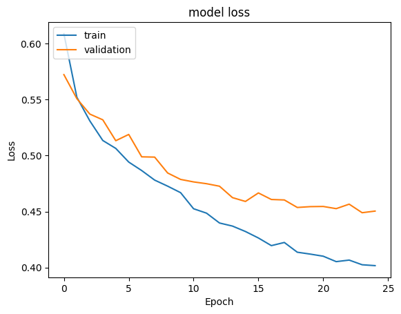

```python
#Plotting Train Loss vs Validation Loss
plt.plot(history_5.history['loss'])
plt.plot(history_5.history['val_loss'])
plt.title('model loss')
plt.ylabel('Loss')
plt.xlabel('Epoch')
plt.legend(['train', 'validation'], loc='upper left')
plt.show()
```

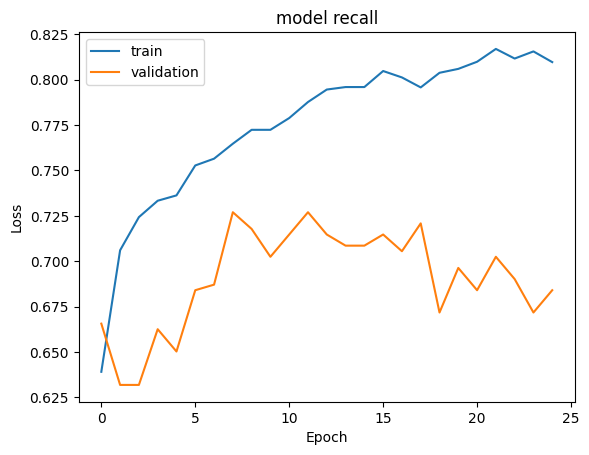

```python
#Plotting Train recall vs Validation recall
plt.plot(history_5.history['recall'])
plt.plot(history_5.history['val_recall'])
plt.title('model recall')
plt.ylabel('Loss')
plt.xlabel('Epoch')
plt.legend(['train', 'validation'], loc='upper left')
plt.show()
```

```python
y_train_pred = model_5.predict(X_train_smote)
#Predicting the results using 0.5 as the threshold
y_train_pred = (y_train_pred > 0.5)
y_train_pred
```

```
319/319 ━━━━━━━━━━━━━━━━━━━━ 1s 2ms/step
```

```
array([[ True],
       [False],
       [False],
       ...,
       [ True],
       [ True],
       [ True]])
```

```python
y_val_pred = model_5.predict(X_val)
#Predicting the results using 0.5 as the threshold
y_val_pred = (y_val_pred > 0.5)
y_val_pred
```

```
50/50 ━━━━━━━━━━━━━━━━━━━━ 0s 1ms/step
```

```
array([[False],
       [False],
       [False],
       ...,
       [False],
       [ True],
       [ True]])
```

```python
model_name = "NN with SMOTE,Adam & Dropout"

train_metric_df.loc[model_name] = recall_score(y_train_smote,y_train_pred)
valid_metric_df.loc[model_name] = recall_score(y_val,y_val_pred)
```

**Classification report**

```python
cr=classification_report(y_train_smote,y_train_pred)
print(cr)
```

```
              precision    recall  f1-score   support

           0       0.84      0.83      0.84      5096
           1       0.83      0.84      0.84      5096

    accuracy                           0.84     10192
   macro avg       0.84      0.84      0.84     10192
weighted avg       0.84      0.84      0.84     10192
```

```python
#classification report
cr=classification_report(y_val,y_val_pred)  ## Complete the code to check the model's performance on the validation set
print(cr)
```

```
              precision    recall  f1-score   support

           0       0.91      0.82      0.86      1274
           1       0.49      0.68      0.57       326

    accuracy                           0.79      1600
   macro avg       0.70      0.75      0.72      1600
weighted avg       0.82      0.79      0.80      1600
```

**Confusion matrix**

```python
#Calculating the confusion matrix
confusion_matrix(y_train_smote, y_train_pred)
```

```
array([[4243,  853],
       [ 804, 4292]])
```

```python
#Calculating the confusion matrix
confusion_matrix(y_val,y_val_pred)  ## Complete the code to check the model's performance on the validation set
```

```
array([[1041,  233],
       [ 103,  223]])
```

## Model Performance Comparison and Final Model Selection

```python
print("Training performance comparison")
train_metric_df
```

```
Training performance comparison
```

[output not shown]

```python
print("Validation set performance comparison")
valid_metric_df
```

```
Validation set performance comparison
```

[output not shown]

```python
train_metric_df - valid_metric_df
```

[output not shown]

MY CONCLUSION ON BEST MODEL

The NN with SMOTE & SGD model has the best balance between training performance (0.655808) and validation performance (0.644172), with the smallest validation difference (0.011637). This suggests it generalizes well and performs consistently across both training and validation sets.

```python
y_test_pred = model_3.predict(X_test)
y_test_pred = (y_test_pred > 0.5)
print(y_test_pred)
```

```
63/63 ━━━━━━━━━━━━━━━━━━━━ 0s 2ms/step
[[False]
 [False]
 [False]
 ...
 [ True]
 [False]
 [False]]
```

```python
#lets print classification report
cr=classification_report(y_test,y_test_pred)
print(cr)
```

```
              precision    recall  f1-score   support

           0       0.89      0.72      0.80      1593
           1       0.38      0.66      0.48       407

    accuracy                           0.71      2000
   macro avg       0.63      0.69      0.64      2000
weighted avg       0.79      0.71      0.73      2000
```

```python
#Calculating the confusion matrix
confusion_matrix(y_test,y_test_pred)
```

```
array([[1153,  440],
       [ 140,  267]])
```

## Actionable Insights and Business Recommendations

1. MY CONCLUSION ON BEST MODEL

The NN with SMOTE & SGD model has the best balance between training performance (0.655808) and validation performance (0.644172), with the smallest validation difference (0.011637). This suggests it generalizes well and performs consistently across both training and validation sets.

1. Based on the models and their performance metrics, I am putting below some potential but actionable insights as well as some recommendations for the bank to target **Reduced Customer Churn**:

Actionable Insights:

- Customer Segmentation:

  High-Risk Customers: Identify customers with high churn probability using the model. Focus on customers with lower credit scores, higher age, and lower tenure as they might be more likely to leave.

  Active Members: Customers who are active members are less likely to churn. Encourage inactive members to engage more with the bank’s products and services.
- Product Offerings: Customized Products: Offer tailored products to customers based on their profiles. For example, younger customers might be interested in digital banking solutions, while older customers might prefer traditional banking services.
  - Cross-Selling: Increase the number of products a customer uses. Customers with more products are less likely to leave.
- Customer Service: Personalized Support: Provide personalized customer support to high-risk customers. Regular check-ins and personalized offers can make them feel valued.
- Feedback Mechanism: Implement a robust feedback mechanism to understand customer pain points and address them promptly.
- Credit Score Improvement: Financial Advisory Services: Offer financial advisory services to help customers improve their credit scores. Customers with better credit scores are less likely to churn.
- Geographical Focus: Targeted Campaigns: Run targeted campaigns in regions with higher churn rates. Understand regional preferences and tailor services accordingly.

Recommendations:

- Model Monitoring: Regularly monitor the performance of the chosen model (NN with SMOTE & SGD) to ensure it continues to provide accurate predictions. Update the model as needed with new data.
- Customer Engagement Programs: Develop programs to increase customer engagement, such as loyalty programs, rewards for active members, and special offers for long-term customers.
- Data-Driven Decisions: Use insights from the model to make data-driven decisions. For example, if the model indicates that a particular demographic is more likely to churn, focus retention efforts on that group.
- Employee Training: Train customer service representatives to recognize signs of potential churn and take proactive steps to retain customers.
- Regular Analysis: Conduct regular analysis of churn data to identify new trends and adjust strategies accordingly.

By implementing these insights and recommendations, the bank can improve customer retention and reduce churn rates effectively.